# Diseño en bloques Split-plot

15/05, 2019

## Prueba

`10:00`

## Diseño en bloques

## Diseño en bloques

- Cuando sabemos que las unidades experimentales por naturaleza no son homogéneas
- Cuando por necesidades técnicas o experimentales para controlar la heterogeneidad de una variable que no es la de interés, por eso hay un efecto a *Bloquear*
  - Medir el desgaste de 4 marcas de neumáticos en 3 modelos de autos
  - Determinar el efecto de 3 técnicas de medir actividad fotosintética en 10 plantas distintas
  - Estudio de una dieta en disminución de colesterol en Hombres y mujeres

## Ejemplo

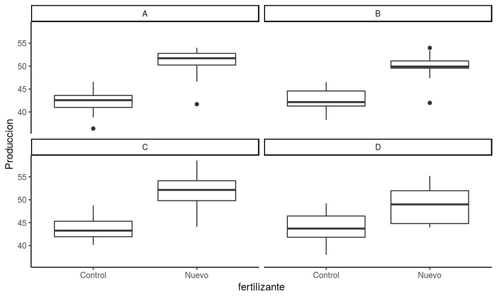

## Como generamos un ANOVA en bloques en R

- Basarse en clase [como formular tu ANOVA](http://www.derek-corcoran-barrios.com/AyudantiaStatsPres/Clase7/Clase7.html#1)
  - ¿Hay variables Anidadas?
  - ¿Hay variables fijas?
  - ¿Hay variables aleatorias?
  - Tienen 5 minutos para revisarlo

`05:00`

## Como generamos un ANOVA en bloques en R

- ¿Hay variables Anidadas?
  - Si: *fertilizante* dentro de *Parcela*
- ¿Hay variables fijas?
  - Si: *fertilizante*
- ¿Hay variables aleatorias?
  - Si: *Parcela*

```r
Bloques <- aov(Produccion ~ fertilizante + Error(Parcela/fertilizante), data = Juan1)
```

## Resultado

```
##
## Error: Parcela
##           Df Sum Sq Mean Sq F value Pr(>F)
## Residuals  3  52.47   17.49
##
## Error: Parcela:fertilizante
##              Df Sum Sq Mean Sq F value  Pr(>F)
## fertilizante  1 1616.7  1616.7   78.55 0.00303 **
## Residuals     3   61.7    20.6
## ---
## Signif. codes:  0 '***' 0.001 '**' 0.01 '*' 0.05 '.' 0.1 ' ' 1
##
## Error: Within
##            Df Sum Sq Mean Sq F value Pr(>F)
## Residuals 112   1034   9.232
```

## Ejemplo 2

El vecino de Don Juan, Don Pedro el Campesino, tiene 4 parcelas de los mismos tamaños que su amigo, pero están cada uno a cierta distancia de un cerro, que le tapa la luz en parte del día, por lo que además registra el número de horas con luz que tiene cada parcela, debe hacer el mismo diseño?

## Ejemplo 2

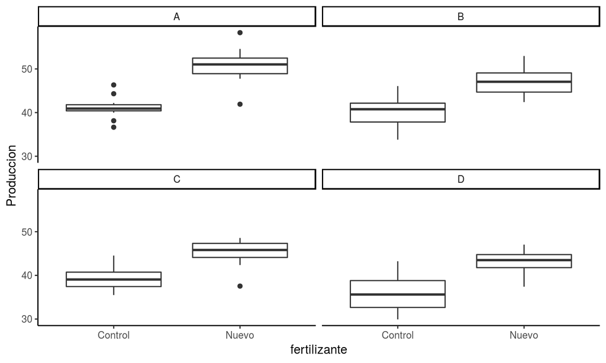

## Como generamos un ANOVA en bloques en R

- Basarse en clase [como formular tu ANOVA](http://www.derek-corcoran-barrios.com/AyudantiaStatsPres/Clase7/Clase7.html#1)
  - ¿Hay variables Anidadas?
  - ¿Hay variables fijas?
  - ¿Hay variables aleatorias?
  - Tienen 5 minutos para revisarlo

`05:00`

## Como generamos un ANOVA en bloques en R

- ¿Hay variables Anidadas?
  - Si: *fertilizante* dentro de *Parcela*
- ¿Hay variables fijas?
  - Si: *fertilizante* y *Parcela*
- ¿Hay variables aleatorias?
  - No

```r
Bloques <- aov(Produccion ~ fertilizante + Parcela/fertilizante, data = Pedro1)
```

## Resultado

```
##                       Df Sum Sq Mean Sq F value   Pr(>F)
## fertilizante           1 1667.5  1667.5 169.962  < 2e-16 ***
## Parcela                3  684.5   228.2  23.256 8.93e-12 ***
## fertilizante:Parcela   3   59.3    19.8   2.016    0.116
## Residuals            112 1098.8     9.8
## ---
## Signif. codes:  0 '***' 0.001 '**' 0.01 '*' 0.05 '.' 0.1 ' ' 1
```

## Ejemplo 2 ¿Otra opcion?

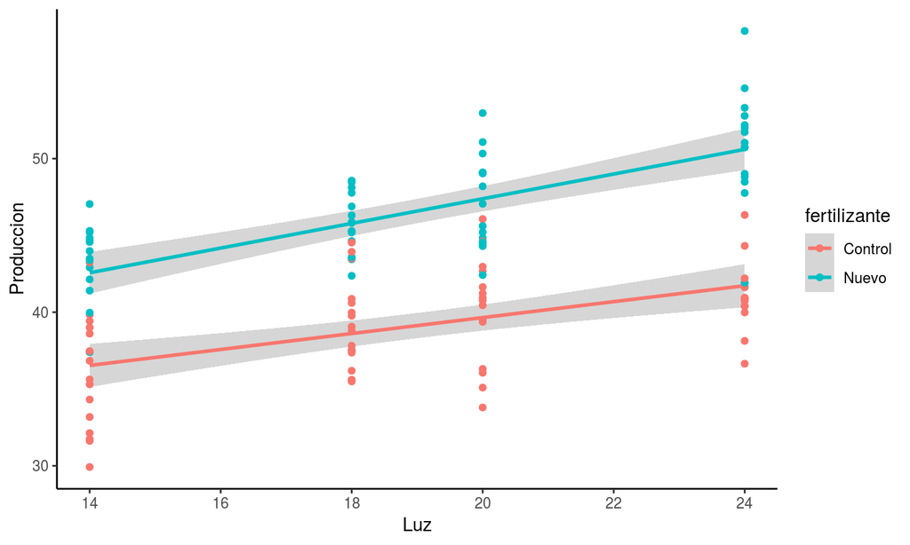

## Ejemplo 2 ¿Otra opcion?

```r
lineal <- lm(Produccion ~ fertilizante + Luz/fertilizante, data = Pedro1)
car::Anova(lineal, type = 2)
```

```
## Anova Table (Type II tests)
##
## Response: Produccion
##                   Sum Sq  Df  F value    Pr(>F)
## fertilizante     1667.48   1 171.2752 < 2.2e-16 ***
## Luz               681.78   1  70.0288 1.506e-13 ***
## fertilizante:Luz   31.54   1   3.2396   0.07448 .
## Residuals        1129.34 116
## ---
## Signif. codes:  0 '***' 0.001 '**' 0.01 '*' 0.05 '.' 0.1 ' ' 1
```

## Ejemplo 2 ¿Otra opcion?

```r
broom::glance(lineal)
```

| r.squared | adj.r.squared | sigma | statistic | p.value | df | logLik | AIC | BIC | deviance | df.residual |
| --- | --- | --- | --- | --- | --- | --- | --- | --- | --- | --- |
| 0.68 | 0.67 | 3.12 | 81.51 | 0 | 4 | -304.79 | 619.57 | 633.51 | 1129.34 | 116 |

## Ejemplo 2 ¿Otra opcion?

```r
broom::tidy(lineal)
```

| term | estimate | std.error | statistic | p.value |
| --- | --- | --- | --- | --- |
| (Intercept) | 29.27 | 2.16 | 13.55 | 0.00 |
| fertilizanteNuevo | 2.05 | 3.06 | 0.67 | 0.50 |
| Luz | 0.52 | 0.11 | 4.64 | 0.00 |
| fertilizanteNuevo:Luz | 0.28 | 0.16 | 1.80 | 0.07 |

## Diseño Split-plot

## Diseño Split-plot

- Tenemos un diseño en bloques, y en cada bloque, tenemos subplots
- Ejemplo

Don Juan quiere diversificar su portafolio de inversiones, por lo que a pensado en plantar mas variedades de manzanas además de *Fuji* como *Granny Smith* y *Red*, pero su otro vecino Don Rodrigo le comenta que con otras variedades el nuevo fertilizante no es tan bueno. ¿Como debiera diseñar el experimento Don Juan para ver si Don Rodrigo tiene razón?

## Ejemplo

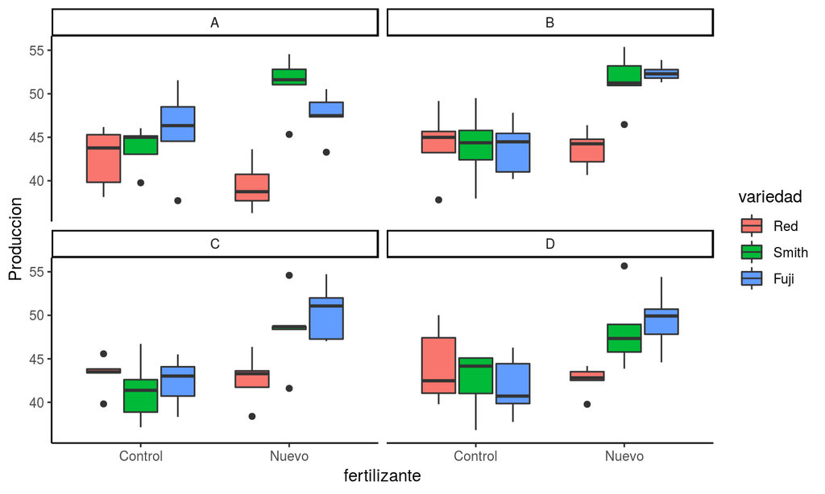

## Como generamos un ANOVA split-block en R

- Basarse en clase [como formular tu ANOVA](http://www.derek-corcoran-barrios.com/AyudantiaStatsPres/Clase7/Clase7.html#1)
  - ¿Hay variables Anidadas?
  - ¿Hay variables fijas?
  - ¿Hay variables aleatorias?
  - Tienen 5 minutos para revisarlo

`05:00`

## Como generamos un ANOVA split-plot en R

```r
split <- aov(Produccion ~ fertilizante * variedad + Error(Parcela/fertilizante), data = Juan2)
```

## Resultados

```
##
## Error: Parcela
##           Df Sum Sq Mean Sq F value Pr(>F)
## Residuals  3   68.7    22.9
##
## Error: Parcela:fertilizante
##              Df Sum Sq Mean Sq F value Pr(>F)
## fertilizante  1  479.4   479.4   30.24 0.0118 *
## Residuals     3   47.6    15.9
## ---
## Signif. codes:  0 '***' 0.001 '**' 0.01 '*' 0.05 '.' 0.1 ' ' 1
##
## Error: Within
##                        Df Sum Sq Mean Sq F value   Pr(>F)
## variedad                2  369.4  184.69   16.01 8.14e-07 ***
## fertilizante:variedad   2  448.7  224.34   19.45 6.12e-08 ***
## Residuals             108 1245.9   11.54
## ---
## Signif. codes:  0 '***' 0.001 '**' 0.01 '*' 0.05 '.' 0.1 ' ' 1
```